# Lab 1

Xin Zhang

2/4/2019

Part 1: Building the Book

The last word is ‘pseudo-class’

Deliverable (2): Write a paragraph on the biggest problem you encountered when you were building the book, and how you managed to solve it.

The biggest problem is on the Condition section. There are severals lines, in which the package ‘testthat’ is used. Though I updated this package from Hadley’s Github, the code can not be successfuly run. Susan helped me with this by commenting those lines.

Part 2: Weather Station

```r
library(readr)
weather <- read_fwf("ftp://ftp.ncdc.noaa.gov/pub/data/ushcn/v2.5/ushcn-v2.5-stations.txt",col_positions = fwf_widths(c(2,1,2,6,9,10,7,3,31,7,7,7,3),col_names = c("COUNTRY CODE ", "NETWORK CODE","ID PLACEHOLDERS (\"00\")","COOP ID", "LATITUDE", "LONGITUDE", "ELEVATION","STATE", "NAME", "COMPONENT 1 (COOP ID)","COMPONENT 2 (COOP ID)","COMPONENT 3 (COOP ID)", "UTC_OFFSET")))
```

Creat the plot

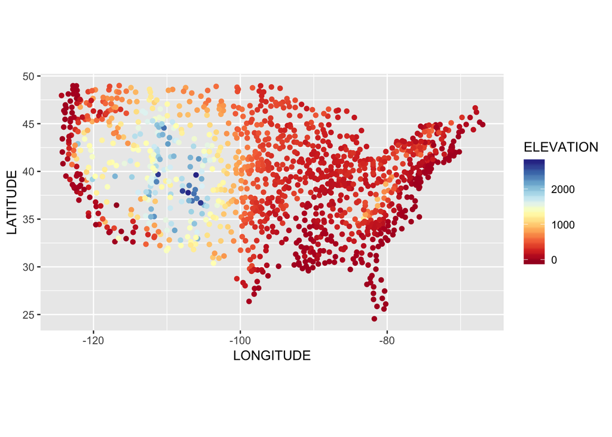

```r
library(ggplot2)
library(RColorBrewer)
p<-ggplot()+geom_point(data=weather,aes(y=LATITUDE,x=LONGITUDE,colour=ELEVATION))+scale_color_gradientn( colours = brewer.pal( 11, "RdYlBu" ))+ coord_fixed(1.3) +  guides(fill=FALSE)
p
```

Include the state information and time zone

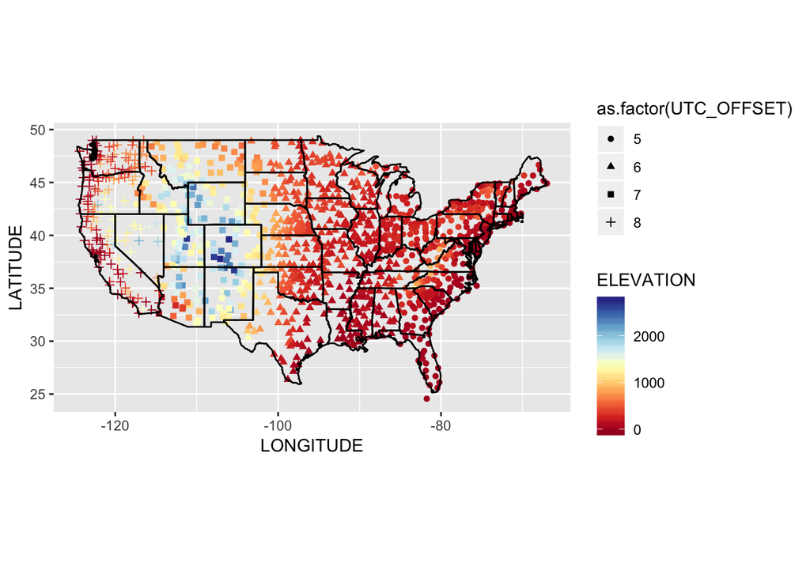

```r
library(ggmap)
library(maps)
library(mapdata)
states <- map_data("state")
p <- ggplot()+geom_point(data=weather,aes(y=LATITUDE,x=LONGITUDE,colour=ELEVATION,shape = as.factor(UTC_OFFSET)))+scale_color_gradientn( colours = brewer.pal( 11, "RdYlBu" ))+ coord_fixed(1.3) +  guides(fill=FALSE)
p + geom_path(data = states,aes(x = long, y = lat, group = group), color = "black")
```

Download .gz file and open with tools available in R.

```r
download.file("ftp://ftp.ncdc.noaa.gov/pub/data/ushcn/v2.5/ushcn.tavg.latest.raw.tar.gz",destfile = "ushcn.tavg.latest.raw.tar.gz")
untar("ushcn.tavg.latest.raw.tar.gz")
```

Check the number of files inside the file ushcn.tavg.latest.raw.tar.gz and the name of the file containing the temperature data of your hometowns or Fort Dodge, IA (please specify).

```r
library(dplyr)
files <- list.files("ushcn.v2.5.5.20190206")
cat('total number of files is', length(files))
```

```
## total number of files is 1218
```

```r
weather %>% filter(grepl("FORT DODGE", weather$NAME)) %>% select(`COUNTRY CODE `,`NETWORK CODE`,"ID PLACEHOLDERS (\"00\")","COOP ID" ) %>% paste(collapse = "") %>% grep(files) -> index
cat('The name of the file containing the temperature data of Fort Dodge, IA is',files[index])
```

```
## The name of the file containing the temperature data of Fort Dodge, IA is USH00132999.raw.tavg
```

There are 1218 files inside the gz file. The name of the file containing the temperature data of Fort Dodge is “USH00132999.raw.tavg”